# Introduction to SC19060

# 7.10

In Example 7.18, leave-one-out (n-fold) cross validation was used to select the best fitting model. Repeat the analysis replacing the Log-Log model with a cubic polynomial model. Which of the four models is selected by the cross validation procedure? Which model is selected according to maximum adjusted $R^{2}$?

# Answer

```r
library(DAAG)
attach(ironslag)
n <- length(magnetic) #in DAAG ironslag
e1 <- e2 <- e3 <- e4 <- numeric(n)
# for n-fold cross validation
# fit models on leave-one-out samples
for (k in 1:n) {
    y <- magnetic[-k]
    x <- chemical[-k]

    J1 <- lm(y ~ x)
    yhat1 <- J1$coef[1] + J1$coef[2] * chemical[k]
    e1[k] <- magnetic[k] - yhat1

    J2 <- lm(y ~ x + I(x^2))
    yhat2 <- J2$coef[1] + J2$coef[2] * chemical[k] +
             J2$coef[3] * chemical[k]^2
    e2[k] <- magnetic[k] - yhat2

    J3 <- lm(log(y) ~ x)
    logyhat3 <- J3$coef[1] + J3$coef[2] * chemical[k]
    yhat3 <- exp(logyhat3)
    e3[k] <- magnetic[k] - yhat3

    J4 <- lm(y ~ x + I(x^2) + I(x^3))
    yhat4 <- J4$coef[1] + J4$coef[2] * chemical[k] +
                J4$coef[3] * chemical[k]^2 +
                J4$coef[4] * chemical[k]^3
    e4[k] <- magnetic[k] - yhat4
}
```

```r
c(mean(e1^2),mean(e2^2),mean(e3^2),mean(e4^2))
```

```
## [1] 19.55644 17.85248 18.44188 18.17756
```

```r
#the estimates of prediction error
```

```r
L1<-lm(magnetic ~ chemical)
L2<-lm(magnetic ~ chemical + I(chemical^2))
L3<-lm(log(magnetic) ~ chemical)
L4<-lm(log(magnetic) ~ log(chemical))
round(c(summary(L1)$adj.r.square,summary(L2)$adj.r.square,summary(L3)$adj.r.square,summary(L4)$adj.r.square),4)
```

```
## [1] 0.5282 0.5768 0.5281 0.4871
```

```r
#the adjusted R-square
```

From the estimates of prediction error we can see that the quadratic module would still be the best fit for the data, and according to maximum adjusted $R{^2}$, we wil also choose the Module2.

```r
L2
```

```
##
## Call:
## lm(formula = magnetic ~ chemical + I(chemical^2))
##
## Coefficients:
##   (Intercept)       chemical  I(chemical^2)
##      24.49262       -1.39334        0.05452
```

The fitted regression equation for Model 2 is $\hat{Y}=24.49262-1.39334 X+0.05452 X^{2}$

## 2019/11/22

## 8.3

The Count 5 test for equal variances in Section 6.4 is based on the maximum number of extreme points. Example 6.15 shows that the Count 5 criterion is not applicable for unequal sample sizes. Implement a permutation test for equal variance based on the maximum number of extreme points that applies when sample sizes are not necessarily equal.

```r
maxout <- function(x, y) {
X <- x - mean(x)
Y <- y - mean(y)
outx <- sum(X > max(Y)) + sum(X < min(Y))
outy <- sum(Y > max(X)) + sum(Y < min(X))
return(as.integer(max(c(outx, outy)) > 5))
}

n1 <- n2 <- 20
mu1 <- mu2 <- 0
sigma1 <- sigma2 <- 1
m <- 1000

#The Count 5 test for equal variance
alphahat <- mean(replicate(m, expr={
x <- rnorm(n1, mu1, sigma1)
y <- rnorm(n2, mu2, sigma2)
x <- x - mean(x) #centered by sample mean
y <- y - mean(y)
maxout(x, y)
}))

#permutation test for equal variance
R <- 999
x <- rnorm(n1, mu1, sigma1)
y <- rnorm(n2, mu2, sigma2)
x <- x - mean(x) #centered by sample mean
y <- y - mean(y)
z <- c(x, y)
n<-length(x)
K <- 1:n
reps <- numeric(R)
t0 <- alphahat
for (i in 1:R) {
k <- sample(K, size = n, replace = FALSE)
x1 <- z[k]
y1 <- z[-k] #complement of x1
reps[i] <- mean(maxout(x,y))
}
p <- mean(abs(c(t0, reps)) >= abs(t0))
round(c(t0,p),3)
```

```
## [1] 0.057 0.001
```

## Question2

Power comparison (distance correlation test versus ball covariance test) Model 1: Y = X/4 + e Model 2: Y = X/4 × e X ∼ N(02, I2), e ∼ N 02, I2), X and e are independent

```r
dCov <- function(x, y) {
x <- as.matrix(x)
y <- as.matrix(y)
n <- nrow(x)
m <- nrow(y)
if (n != m || n < 2) stop("Sample sizes must agree")
if (! (all(is.finite(c(x, y)))))
stop("Data contains missing or infinite values")
Akl <- function(x) {
d <- as.matrix(dist(x))
m <- rowMeans(d)
M <- mean(d)
a <- sweep(d, 1, m)
b <- sweep(a, 2, m)
return(b + M)
}
A <- Akl(x)
B <- Akl(y)
dCov <- sqrt(mean(A * B))
}
```

```r
ndCov2 <- function(z, ix, dims) {
  p <- dims[1]
  q1 <- dims[2] + 1
  d <- p + dims[2]
  x <- z[ , 1:p]
  y <- z[ix, q1:d]
  return(nrow(z) * dCov(x, y)^2)
}

library(MASS)
sigma<-matrix(c(7,3,3,4),2,2)
x<-mvrnorm(n=100,rep(0,2),sigma)
e<-mvrnorm(n=100,rep(0,2),sigma)
y1<-x/4+e
y2<-x/4*e

library(boot)
library(Ball)
z1<-matrix(rbind(x,y1),100,4)
z2<-matrix(rbind(x,y2),100,4)
boot.obj1 <- boot(data = z1, statistic = ndCov2, R = 999,
sim = "permutation", dims = c(2, 2))
boot.obj2 <- boot(data = z2, statistic = ndCov2, R = 999,
sim = "permutation", dims = c(2, 2))
tb1 <- c(boot.obj1$t0, boot.obj1$t)
tb2 <- c(boot.obj2$t0, boot.obj2$t)

m<-1e2
p.values <- matrix(NA,m,4)
for(i in 1:m){
p.values[i,1] <- mean(tb1 >= boot.obj1$t0)
p.values[i,2] <- mean(tb2 >= boot.obj2$t0)
p.values[i,3] <- bcov.test(x=x,y=y1,R=999,seed=i*54321)$p.value
p.values[i,4] <- bcov.test(x=x,y=y2,R=999,seed=i*54321)$p.value
}
alpha <- 0.1;
pow <- colMeans(p.values<alpha)
pow
```

```
## [1] 1.00 1.00 0.88 1.00
```

## 2019/11/29

Implement a random walk Metropolis sampler for generating the standard Laplace distribution (see Exercise 3.2). For the increment, simulate from a normal distribution. Compare the chains generated when different variances are used for the proposal distribution. Also, compute the acceptance rates of each chain.

```r
rw.Metropolis <- function(sigma, x0, N) {
  x <- numeric(N)
  x[1] <- x0
  u <- runif(N)
  k <- 0
  for (i in 2:N) {
    y <- rnorm(1, x[i-1], sigma)
        if (u[i] <= (0.5*exp(-abs(y)) / (0.5*exp(-abs(x[i-1])))))
          x[i] <- y else {
            x[i] <- x[i-1]
            k <- k + 1
          }
    }
  return(list(x=x, k=k))
}
N <- 2000
sigma <- c(.05, .5, 2, 16)
x0 <- 25
rw1 <- rw.Metropolis(sigma[1], x0, N)
rw2 <- rw.Metropolis(sigma[2], x0, N)
rw3 <- rw.Metropolis(sigma[3], x0, N)
rw4 <- rw.Metropolis(sigma[4], x0, N)
#number of candidate points rejected
print(c(rw1$k, rw2$k, rw3$k, rw4$k))
```

```
## [1]   40  373  958 1776
```

```r
print(c(rw1$k/N,rw2$k/N,rw3$k/N,rw4$k/N))
```

```
## [1] 0.0200 0.1865 0.4790 0.8880
```

From the result we can see that both the second chain and the third chain has a rejection rate in the range [0.15,0.5].

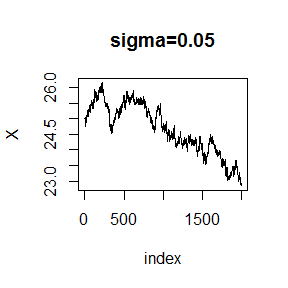

```r
#par(mfrow=c(2,2))
index<-1:N
y1<-rw1$x[index]
y2<-rw2$x[index]
y3<-rw3$x[index]
y4<-rw4$x[index]
plot(index,y1,main="sigma=0.05",type = "l", ylab = "X")
```

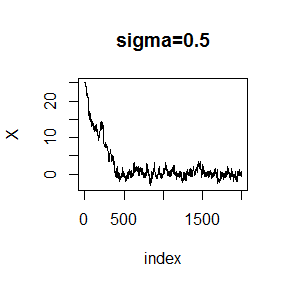

```r
plot(index,y2,main="sigma=0.5",type = "l", ylab = "X")
```

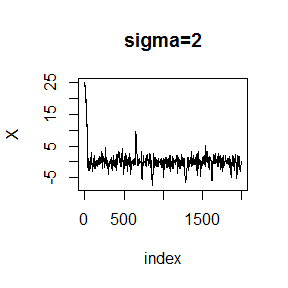

```r
plot(index,y3,main="sigma=2",type = "l", ylab = "X")
```

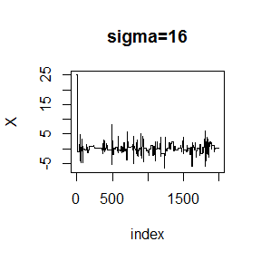

```r
plot(index,y4,main="sigma=16",type = "l", ylab = "X")
```

## 2019/12/06

## 11.1

The natural logarithm and exponential functions are inverses of each other, so that mathematically log(exp x) = exp(log x) = x. Show by example that this property does not hold exactly in computer arithmetic. Does the identity hold with near equality? (See all.equal.)

```r
x<-runif(10)
A<-log(exp(abs(x)))
B<-exp(log(abs(x)))
A
```

```
##  [1] 0.14255592 0.87881147 0.65131549 0.64121936 0.53396491 0.79610121
##  [7] 0.03508336 0.51213755 0.73549429 0.61680371
```

```r
B
```

```
##  [1] 0.14255592 0.87881147 0.65131549 0.64121936 0.53396491 0.79610121
##  [7] 0.03508336 0.51213755 0.73549429 0.61680371
```

```r
A==B
```

```
##  [1] FALSE  TRUE  TRUE  TRUE  TRUE  TRUE FALSE  TRUE FALSE  TRUE
```

```r
isTRUE(all.equal(A,B))
```

```
## [1] TRUE
```

From the result we can see that this property hold with near equality, but doesn’t hold exactly in computer arithmetic.

## 11.5

```r
k<-c(4:25,100,500,1000)
F<-function(a,k){
  M<-2/sqrt(pi*(k-1))*exp(lgamma(k/2)-lgamma((k-1)/2))
  N<-2/sqrt(pi*k)*exp(lgamma((k+1)/2)-lgamma(k/2))
  ck1<-sqrt(a^2*(k-1)/(k-a^2))
  ck2<-sqrt(a^2*k/(k+1-a^2))
  I1<-function(u,k){
    (1+u^2/(k-1))^(-k/2)
  }
  I2<-function(u,k){
    (1+u^2/k)^(-(k+1)/2)
  }
  L<-integrate(I1,lower=0.01,upper=ck1-0.001,rel.tol=.Machine$double.eps^0.25,k=k)$value
  R<-integrate(I2,lower=0.01,upper=ck1-0.001,rel.tol=.Machine$double.eps^0.25,k=k)$value
  AK<-M*L-N*R
}
solution<-numeric(length(k))
for (i in 1:length(k)) {
  f<-function(a) F(a,k[i])
  solution[i]<-uniroot(f,c(0,1.9))$root
}
solution
```

```
##  [1] 0.01269123 0.01229640 0.01204869 0.01188042 0.01175868 0.01166653
##  [7] 0.01159434 0.01153625 0.01148851 0.01144857 0.01141466 0.01138552
## [13] 0.01136020 0.01133800 0.01131837 0.01130090 0.01128524 0.01127113
## [19] 0.01125835 0.01124671 0.01123608 0.01122633 0.01105497 0.01101058
## [25] 0.01100507
```

## A-B-O blood type problem

Use EM algorithm to solve MLE of p and q (consider missing data nAA and nBB).

```r
blood<-function(p,n.obs){
  n<-sum(n.obs)
  na<-n.obs[1]
  nb<-n.obs[2]
  noo<-n.obs[3]
  nab<-n.obs[4]

  pa<-pb<-po<-rep(0,20)
  pa[1]<-p[1]
  pb[1]<-p[2]
  po[1]<-1-p[1]-p[2]
  for (i in 2:20){
    pa.old<-pa[i-1]
    pb.old<-pb[i-1]
    po.old<-po[i-1]

    temp1<-pa.old^2+2*pa.old*po.old
    naa<-na*pa.old^2/temp1
    nao<-2*na*pa.old*po.old/temp1
    temp2<-pb.old^2+2*pb.old*po.old
    nbb<-nb*pb.old^2/temp2
    nbo<-2*nb*pb.old*po.old/temp2
    pa[i]<-(2*naa+nao+nab)/(2*n)
    pb[i]<-(2*nbb+nbo+nab)/(2*n)
    po[i]<-(2*noo+nao+nbo)/(2*n)
  }
  return(list(pa=pa,pb=pb,po=po))
}

n.obs<-c(28,24,41,70)
p<-c(1/3,1/3)
a<-blood(p,n.obs)
p<-a$pa
q<-a$pb
r<-a$po
print(cbind(p,q,r))
```

```
##               p         q         r
##  [1,] 0.3333333 0.3333333 0.3333333
##  [2,] 0.3292434 0.3128834 0.3578732
##  [3,] 0.3276746 0.3107368 0.3615886
##  [4,] 0.3273954 0.3104695 0.3621351
##  [5,] 0.3273519 0.3104328 0.3622153
##  [6,] 0.3273454 0.3104276 0.3622270
##  [7,] 0.3273444 0.3104268 0.3622288
##  [8,] 0.3273443 0.3104267 0.3622290
##  [9,] 0.3273442 0.3104267 0.3622291
## [10,] 0.3273442 0.3104267 0.3622291
## [11,] 0.3273442 0.3104267 0.3622291
## [12,] 0.3273442 0.3104267 0.3622291
## [13,] 0.3273442 0.3104267 0.3622291
## [14,] 0.3273442 0.3104267 0.3622291
## [15,] 0.3273442 0.3104267 0.3622291
## [16,] 0.3273442 0.3104267 0.3622291
## [17,] 0.3273442 0.3104267 0.3622291
## [18,] 0.3273442 0.3104267 0.3622291
## [19,] 0.3273442 0.3104267 0.3622291
## [20,] 0.3273442 0.3104267 0.3622291
```

From the result we can see that after about 4 iterations, p and q converge to 0.32735 and 0.31043, respectively.

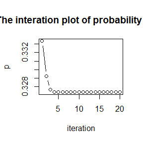

```r
plot(c(1:20),p,xlab = "iteration",ylab='p',type="b",main="The interation plot of probability of 'p'")
```

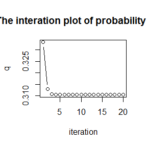

```r
plot(c(1:20),q,xlab = "iteration",ylab='q',type="b",main="The interation plot of probability of 'q'")
```

## 2019/12/13

## 3

Use both for loops and lapply() to fit linear models to the mtcars using the formulas stored in this list:

formulas <- list(

mpg ~ disp,

mpg ~ I(1 / disp),

mpg ~ disp + wt,

mpg ~ I(1 / disp) + wt

)

## Answer

```r
formulas <- list(
  mpg ~ disp,
  mpg ~ I(1 / disp),
  mpg ~ disp + wt,
  mpg ~ I(1 / disp) + wt
)
la<-lapply(formulas,lm,data = mtcars) #use lapply()
la
```

```
## [[1]]
##
## Call:
## FUN(formula = X[[i]], data = ..1)
##
## Coefficients:
## (Intercept)         disp
##    29.59985     -0.04122
##
##
## [[2]]
##
## Call:
## FUN(formula = X[[i]], data = ..1)
##
## Coefficients:
## (Intercept)    I(1/disp)
##       10.75      1557.67
##
##
## [[3]]
##
## Call:
## FUN(formula = X[[i]], data = ..1)
##
## Coefficients:
## (Intercept)         disp           wt
##    34.96055     -0.01772     -3.35083
##
##
## [[4]]
##
## Call:
## FUN(formula = X[[i]], data = ..1)
##
## Coefficients:
## (Intercept)    I(1/disp)           wt
##      19.024     1142.560       -1.798
```

```r
out<-vector("list",length(formulas))
for (i in seq_along(formulas)) {
  out[[i]]<-lm(formulas[[i]], data = mtcars)
}
out #use loop
```

```
## [[1]]
##
## Call:
## lm(formula = formulas[[i]], data = mtcars)
##
## Coefficients:
## (Intercept)         disp
##    29.59985     -0.04122
##
##
## [[2]]
##
## Call:
## lm(formula = formulas[[i]], data = mtcars)
##
## Coefficients:
## (Intercept)    I(1/disp)
##       10.75      1557.67
##
##
## [[3]]
##
## Call:
## lm(formula = formulas[[i]], data = mtcars)
##
## Coefficients:
## (Intercept)         disp           wt
##    34.96055     -0.01772     -3.35083
##
##
## [[4]]
##
## Call:
## lm(formula = formulas[[i]], data = mtcars)
##
## Coefficients:
## (Intercept)    I(1/disp)           wt
##      19.024     1142.560       -1.798
```

## 4

Fit the model mpg ~ disp to each of the bootstrap replicates of mtcars in the list below by using a for loop and lapply(). Can you do it without an anonymous function?

bootstraps <- lapply(1:10, function(i) {

rows <- sample(1:nrow(mtcars), rep = TRUE)

mtcars[rows, ]

})

## Answer

```r
bootstraps <- lapply(1:10, function(i) {
  rows <- sample(1:nrow(mtcars), rep = TRUE)
  mtcars[rows, ]
})
lapply(bootstraps,lm,formula = mpg ~ disp) #use lapply()
```

```
## [[1]]
##
## Call:
## FUN(formula = ..1, data = X[[i]])
##
## Coefficients:
## (Intercept)         disp
##    26.52134     -0.03256
##
##
## [[2]]
##
## Call:
## FUN(formula = ..1, data = X[[i]])
##
## Coefficients:
## (Intercept)         disp
##    29.40837     -0.04075
##
##
## [[3]]
##
## Call:
## FUN(formula = ..1, data = X[[i]])
##
## Coefficients:
## (Intercept)         disp
##    29.62515     -0.04146
##
##
## [[4]]
##
## Call:
## FUN(formula = ..1, data = X[[i]])
##
## Coefficients:
## (Intercept)         disp
##     29.7317      -0.0398
##
##
```

[output cut: 43 more lines]

```
## FUN(formula = ..1, data = X[[i]])
##
## Coefficients:
## (Intercept)         disp
##    31.24010     -0.04399
##
##
## [[10]]
##
## Call:
## FUN(formula = ..1, data = X[[i]])
##
## Coefficients:
## (Intercept)         disp
##    28.15996     -0.03579
```

```r
out<-vector("list",length(bootstraps))
for (i in seq_along(bootstraps)) {
  out[[i]]<-lm(mpg ~ disp, data = bootstraps[[i]])
}
out #use loop
```

```
## [[1]]
##
## Call:
## lm(formula = mpg ~ disp, data = bootstraps[[i]])
##
## Coefficients:
## (Intercept)         disp
##    26.52134     -0.03256
##
##
## [[2]]
##
## Call:
## lm(formula = mpg ~ disp, data = bootstraps[[i]])
##
## Coefficients:
## (Intercept)         disp
##    29.40837     -0.04075
##
##
## [[3]]
##
## Call:
## lm(formula = mpg ~ disp, data = bootstraps[[i]])
##
## Coefficients:
## (Intercept)         disp
##    29.62515     -0.04146
##
##
## [[4]]
##
## Call:
## lm(formula = mpg ~ disp, data = bootstraps[[i]])
##
## Coefficients:
## (Intercept)         disp
##     29.7317      -0.0398
##
##
```

[output cut: 43 more lines]

```
## lm(formula = mpg ~ disp, data = bootstraps[[i]])
##
## Coefficients:
## (Intercept)         disp
##    31.24010     -0.04399
##
##
## [[10]]
##
## Call:
## lm(formula = mpg ~ disp, data = bootstraps[[i]])
##
## Coefficients:
## (Intercept)         disp
##    28.15996     -0.03579
```

## 5

For each model in the previous two exercises, extract
$$R^{2}$$
using the function below.

rsq <- function(mod) summary(mod)$r.squared

## Answer

```r
# exercise 3's lapply()
formulas <- list(
  mpg ~ disp,
  mpg ~ I(1 / disp),
  mpg ~ disp + wt,
  mpg ~ I(1 / disp) + wt
)
la<-lapply(formulas,lm,data = mtcars)
rsq <- function(mod) summary(mod)$r.squared
sapply(la,rsq)
```

```
## [1] 0.7183433 0.8596865 0.7809306 0.8838038
```

```r
# exercise 3's loop
out<-vector("list",length(formulas))
for (i in seq_along(formulas)) {
  out[[i]]<-lm(formulas[[i]], data = mtcars)
}
sapply(out, rsq)
```

```
## [1] 0.7183433 0.8596865 0.7809306 0.8838038
```

```r
# exercise 4's lapply()
bootstraps <- lapply(1:10, function(i) {
  rows <- sample(1:nrow(mtcars), rep = TRUE)
  mtcars[rows, ]
})
a<-lapply(bootstraps,lm,formula = mpg ~ disp)
sapply(a, rsq)
```

```
##  [1] 0.7899909 0.6486319 0.8183109 0.7316967 0.7888718 0.7944227 0.7461593
##  [8] 0.6862949 0.7626672 0.6117390
```

```r
# exercise 4's loop
out<-vector("list",length(bootstraps))
for (i in seq_along(bootstraps)) {
  out[[i]]<-lm(mpg ~ disp, data = bootstraps[[i]])
}
sapply(out, rsq)
```

```
##  [1] 0.7899909 0.6486319 0.8183109 0.7316967 0.7888718 0.7944227 0.7461593
##  [8] 0.6862949 0.7626672 0.6117390
```

## 3

The following code simulates the performance of a t-test for non-normal data. Use sapply() and an anonymous function to extract the p-value from every trial.

trials <- replicate(

100,

t.test(rpois(10, 10), rpois(7, 10)),

simplify = FALSE

)

Extra challenge: get rid of the anonymous function by using [[ directly.

## Answer

```r
trials <- replicate(
  100,
  t.test(rpois(10, 10), rpois(7, 10)),
  simplify = FALSE
)
#use an anonymous function
sapply(trials,function(x) x[["p.value"]])
```

```
##   [1] 0.280779971 0.705193767 0.870278491 0.943101988 0.510669946 0.193018592
##   [7] 0.488417501 0.222464569 0.074094087 0.702090286 0.594813037 0.528076814
##  [13] 0.794952425 0.159087698 0.956469965 0.575621200 0.042853874 0.556637218
##  [19] 0.167266241 0.312118109 0.845479425 0.348976977 0.629947490 0.770394294
##  [25] 0.294866613 0.912959321 0.280674005 0.244109062 0.314333227 0.622952720
##  [31] 0.221639805 0.544156712 0.822654384 0.588507687 0.133978373 0.276233672
##  [37] 0.967980299 0.661643181 0.924551210 0.452331956 0.212522904 0.085664855
##  [43] 0.272814580 0.343724343 0.290426122 0.005118411 0.942234483 0.947098781
##  [49] 0.316496953 0.551701884 0.592352702 0.588888183 0.983936957 0.441716341
##  [55] 0.535261950 0.357742130 0.387979937 0.560930236 0.883481187 0.426304012
##  [61] 0.050200298 0.528922315 0.067928358 0.953792200 0.481596820 0.945733679
##  [67] 0.110442080 0.802890846 0.834207517 0.687813009 0.541827677 0.325368715
##  [73] 0.707348374 0.739308553 0.147288438 0.258661351 0.039871742 0.261398180
##  [79] 0.384588918 0.650384323 0.833540098 0.145286194 0.100281008 0.570172230
##  [85] 0.482368104 0.414403191 0.062532063 0.422677334 0.691021933 0.792109091
##  [91] 0.463541748 0.728671800 0.468135850 0.740911639 0.458163816 0.011005555
##  [97] 0.755858571 0.600103641 0.847586887 0.312225522
```

```r
# use sapply()
sapply(trials,"[[","p.value")
```

```
##   [1] 0.280779971 0.705193767 0.870278491 0.943101988 0.510669946 0.193018592
##   [7] 0.488417501 0.222464569 0.074094087 0.702090286 0.594813037 0.528076814
##  [13] 0.794952425 0.159087698 0.956469965 0.575621200 0.042853874 0.556637218
##  [19] 0.167266241 0.312118109 0.845479425 0.348976977 0.629947490 0.770394294
##  [25] 0.294866613 0.912959321 0.280674005 0.244109062 0.314333227 0.622952720
##  [31] 0.221639805 0.544156712 0.822654384 0.588507687 0.133978373 0.276233672
##  [37] 0.967980299 0.661643181 0.924551210 0.452331956 0.212522904 0.085664855
##  [43] 0.272814580 0.343724343 0.290426122 0.005118411 0.942234483 0.947098781
##  [49] 0.316496953 0.551701884 0.592352702 0.588888183 0.983936957 0.441716341
##  [55] 0.535261950 0.357742130 0.387979937 0.560930236 0.883481187 0.426304012
##  [61] 0.050200298 0.528922315 0.067928358 0.953792200 0.481596820 0.945733679
##  [67] 0.110442080 0.802890846 0.834207517 0.687813009 0.541827677 0.325368715
##  [73] 0.707348374 0.739308553 0.147288438 0.258661351 0.039871742 0.261398180
##  [79] 0.384588918 0.650384323 0.833540098 0.145286194 0.100281008 0.570172230
##  [85] 0.482368104 0.414403191 0.062532063 0.422677334 0.691021933 0.792109091
##  [91] 0.463541748 0.728671800 0.468135850 0.740911639 0.458163816 0.011005555
##  [97] 0.755858571 0.600103641 0.847586887 0.312225522
```

## 7

Implement mcsapply(), a multicore version of sapply(). Can you implement mcvapply(), a parallel version of vapply()? Why or why not?

## Answer

```r
#library(parallel)
#boot_df <- function(x) x[sample(nrow(x), rep = T), ]
#rsquared <- function(mod) summary(mod)$r.square
#boot_lm <- function(i) {
#dat <- boot_df(mtcars)
#rsquared(lm(mpg ~ wt + disp, data = dat))
#}
#n <- 1e4
#system.time(mcsapply(1:n, boot_lm, mc.cores = 4))
```

[output not shown]